# Homework 4

Gurusharan Kunusoth

## Problems

### 1

Suppose you have a random variable $X \sim \text{Binomial}(120, 0.15)$.

#### 1A

Calculate and report the mean and standard deviation of the distribution.

```r
# insert code below
n <- 120
p <- 0.15

mean <- n * p
standard_deviation <- sqrt(n * p * (1 - p))

mean
```

```
## [1] 18
```

```r
standard_deviation
```

```
## [1] 3.911521
```

#### 1B

Calculate and report the probability that X=20, $P(X = 20)$.

```r
# insert code below
n <- 120
p <- 0.15
k <- 20

probability <- choose(n, k) * p^k * (1 - p)^(n - k)

probability
```

```
## [1] 0.08570049
```

#### 1C

Calculate and report the probability that X>=20, $P(X >= 20)$.

```r
# insert code below
n <- 120
p <- 0.15
k <- 20

probability <- 1 - pbinom(k - 1, n, p)

probability
```

```
## [1] 0.3413833
```

#### 1D

Create a graph which displays the binomial distribution of X using vertical segments at each value of X=x, where the height of the segments indicate the probability P(X=x).

- For X >= 20, use a different color for the segments from the rest to help visualize your answer to 1C.
- Only display values on the plot for X <= 50
- You may use functions from `ggprob.R`, or create the graphic using your own code.

(If you want to use `ggprob.R` functions, see discussion 4 file for more specific hints and guidance on the functions.)

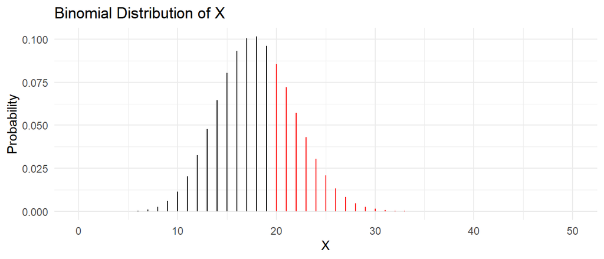

```r
# insert code below
library(ggplot2)

n <- 120
p <- 0.15

x <- 0:n
probabilities <- dbinom(x, n, p)
data <- data.frame(x, probabilities)

data <- data[data$x <= 50, ]

plot <- ggplot(data, aes(x = x, y = probabilities)) +
  geom_segment(aes(xend = x, yend = 0), color = "black") +
  geom_segment(data = data[data$x >= 20, ], aes(xend = x, yend = 0), color = "red") +
  ylim(0, max(data$probabilities)) +
  labs(x = "X", y = "Probability") +
  ggtitle("Binomial Distribution of X") +
  theme_minimal()

plot
```

### 2

What is the probability that $X$ from Question 1 is within one, two, and three standard deviations of the mean? Round each probability to four decimal places.

```r
# insert code below
n <- 120
p <- 0.15

mean <- n * p
standard_deviation <- sqrt(n * p * (1 - p))

lower_bound <- mean - standard_deviation
upper_bound <- mean + standard_deviation
prob_within_one_std <- pbinom(upper_bound, n, p) - pbinom(lower_bound - 1, n, p)

lower_bound <- mean - 2 * standard_deviation
upper_bound <- mean + 2 * standard_deviation
prob_within_two_std <- pbinom(upper_bound, n, p) - pbinom(lower_bound - 1, n, p)

lower_bound <- mean - 3 * standard_deviation
upper_bound <- mean + 3 * standard_deviation
prob_within_three_std <- pbinom(upper_bound, n, p) - pbinom(lower_bound - 1, n, p)

prob_within_one_std <- round(prob_within_one_std, 4)
prob_within_two_std <- round(prob_within_two_std, 4)
prob_within_three_std <- round(prob_within_three_std, 4)

prob_within_one_std
```

```
## [1] 0.6939
```

```r
prob_within_two_std
```

```
## [1] 0.9578
```

```r
prob_within_three_std
```

```
## [1] 0.997
```

### 3

Draw a graph of the binomial distribution from Questions 1 and 2 (similar to what you did in Question 1D with the vertical segments). You may use functions from `ggprob.R`, or create the graphic using your own code. Only display values for X between 5 and 35.

Add vertical lines with different line types at the end points of the intervals 1, 2, and 3 sigma from the mean:

- solid for $\mu \pm \sigma$
- dashed for $\mu \pm 2\sigma$
- dotted for $\mu \pm 3\sigma$

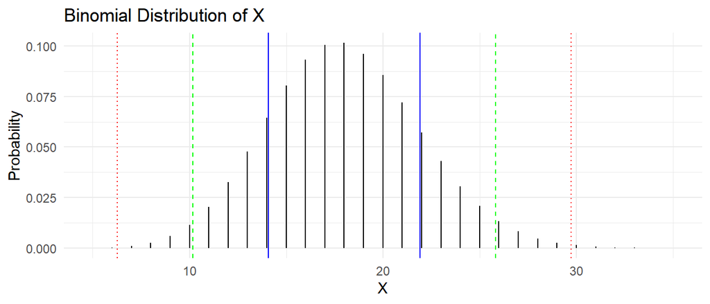

```r
# insert code below
library(ggplot2)

n <- 120
p <- 0.15

mean <- n * p
standard_deviation <- sqrt(n * p * (1 - p))

x <- 5:35
probabilities <- dbinom(x, n, p)
data <- data.frame(x, probabilities)

plot <- ggplot(data, aes(x = x, y = probabilities)) +
  geom_segment(aes(xend = x, yend = 0), color = "black") +
  ylim(0, max(data$probabilities)) +
  labs(x = "X", y = "Probability") +
  ggtitle("Binomial Distribution of X") +
  theme_minimal()

plot <- plot +
  geom_vline(xintercept = c(mean - standard_deviation, mean + standard_deviation),
             linetype = "solid", color = "blue") +
  geom_vline(xintercept = c(mean - 2 * standard_deviation, mean + 2 * standard_deviation),
             linetype = "dashed", color = "green") +
  geom_vline(xintercept = c(mean - 3 * standard_deviation, mean + 3 * standard_deviation),
             linetype = "dotted", color = "red")

plot
```

### 4

#### 4A

```r
# insert code below
n <- 100
p <- 0.5

k <- 30

probability <- pbinom(k, n, p)

probability
```

```
## [1] 3.92507e-05
```

### 5

#### 5A

Create a tibble where each row corresponds to a binomial distribution with the following columns:

- `n` for $n = 1000,1005,1010, 1015, \ldots, 25,000$
- `p` equal to 0.25 for each row
- `mu` equal to the mean
- `sigma` equal to the standard deviation
- `q.90` equal to the 0.90 quantile of the distribution
- `z = (q.90 - mu)/sigma`, the standardized z-score of the quantile
- `prob` equal to $P(X \ge q.90)$, a right-tail probability for the distribution in each row

Display all columns and the rows of this table for which $n$ is a multiple of 5000.

```r
# insert code below
binom_Dist = tibble(
  n = seq(1000, 25000, by = 5),
  p = 0.25,
  mu = n * p,
  sigma = sqrt(n * p * (1 - p)),
  q.90 = qbinom(.9, n, p),
  z = (q.90 - mu)/sigma,
  prob = 1 - pnorm(n, p, q.90)
)

print(binom_Dist)
```

```
## # A tibble: 4,801 × 7
##        n     p    mu sigma  q.90     z      prob
##    <dbl> <dbl> <dbl> <dbl> <dbl> <dbl>     <dbl>
##  1  1000  0.25  250   13.7   268  1.31 0.0000956
##  2  1005  0.25  251.  13.7   269  1.29 0.0000938
##  3  1010  0.25  252.  13.8   270  1.27 0.0000921
##  4  1015  0.25  254.  13.8   271  1.25 0.0000904
##  5  1020  0.25  255   13.8   273  1.30 0.0000937
##  6  1025  0.25  256.  13.9   274  1.28 0.0000920
##  7  1030  0.25  258.  13.9   275  1.26 0.0000904
##  8  1035  0.25  259.  13.9   277  1.31 0.0000936
##  9  1040  0.25  260   14.0   278  1.29 0.0000920
## 10  1045  0.25  261.  14.0   279  1.27 0.0000903
## # ℹ 4,791 more rows
```

#### 5B

Use a line plot to show the relationship between $n$ on the x axis and $z$ on the y axis. Add a smooth curve to highlight the trend. Describe the pattern you see.

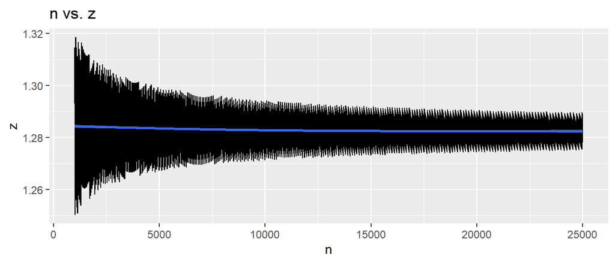

```r
# insert code below
plot = ggplot(binom_Dist, aes(x = n, y = z)) +
  geom_line() + labs(title = "n vs. z", x = "n", y = "z") + geom_smooth()

print(plot)
```

From 1000 to 5500, a gentle negative curve is observed, while beyond 5500, the trend remains predominantly linear, albeit with a slight negative inclination.

#### 5C

What is the average of the values of $z$ for $n > 15,000$?

```r
# insert code below
temp_Table = binom_Dist %>%
  filter(n > 15000)
avg_Values = mean(temp_Table$z)

print(avg_Values)
```

```
## [1] 1.282477
```

#### 5D

Plot the right tail probability `prob` on y axis versus `n` on the x axis.

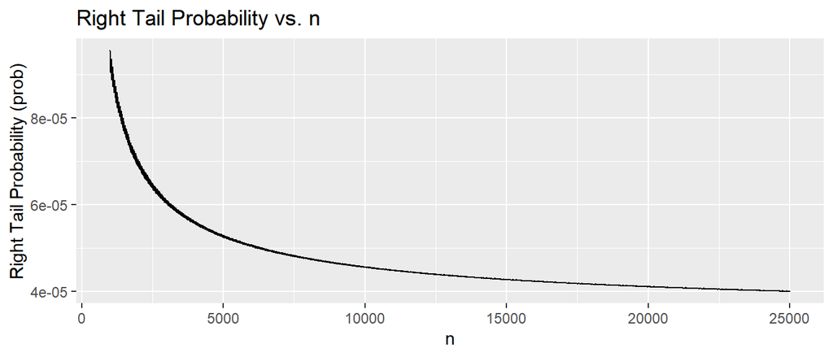

```r
# insert code below
probPlot = ggplot(binom_Dist, aes(x = n, y = prob)) + geom_line() +
  labs(title = "Right Tail Probability vs. n", x = "n", y = "Right Tail Probability (prob)")

print(probPlot)
```

#### 5E

What is the average of the values of `prob` for $n > 15,000$?

```r
# insert code below
temp_Table = binom_Dist %>%
  filter(n > 15000)
avg_Values = mean(temp_Table$prob)

print(avg_Values)
```

```
## [1] 4.11551e-05
```